# Regimes

Regimes by role, intervening region against its partner (both intervening: North against South):CD competitive displacement (intervener up, partner down)PL production leakage (intervener down, partner up)DC dual contractionDE dual expansionCC contained (partner within ±0.003%)

**Runs** The choice is remembered across the Regimes, Results and Highlights tabs.

## Regimes: 180 runs: all (who intervenes x five policies)

Each chip is the value-added regime of one run: an intervention (rows, in scenario order) carried out by the North, the South or both, under no rule, North money, no rule, South money, South adjusts, North adjusts, both adjust. Hover a chip for its run.

| Intervention | North intervenes no rule N$ | North intervenes no rule S$ | North intervenes S adjusts | North intervenes N adjusts | North intervenes both adjust | South intervenes no rule N$ | South intervenes no rule S$ | South intervenes S adjusts | South intervenes N adjusts | South intervenes both adjust | Both intervene no rule N$ | Both intervene no rule S$ | Both intervene S adjusts | Both intervene N adjusts | Both intervene both adjust |
| --- | --- | --- | --- | --- | --- | --- | --- | --- | --- | --- | --- | --- | --- | --- | --- |
| **sc1 HH-Food** | PL | DE | PL | DC | PL | DE | DC | PL | DE | PL | DE | CC | CD | DE | DE |
| **sc2 HH-Energy** | CD | CD | CD | CD | CD | DE | CD | CC | DE | DE | DE | CC | CD | DE | DE |
| **sc3 HH-Wood** | CC | CC | CC | CC | CC | CC | CC | CC | CC | CC | CC | CC | CD | CC | CC |
| **sc4 Gov-Plastics** | DC | DC | DC | CC | DC | CC | CC | CC | CC | CC | DC | DC | DC | CC | DC |
| **sc5 Int-Wood** | PL | PL | PL | CC | PL | DC | CC | DC | DC | DC | DC | DC | DC | DC | DC |
| **sc6 Int-Pulp** | CC | CC | CC | CC | CC | CC | CC | CC | PL | PL | CD | DC | DC | CC | CD |
| **sc7 Int-Plastics** | CC | DC | CC | DC | DC | DC | DC | DC | DC | DC | DC | DC | DC | DC | DC |
| **sc8 Int-Metal** | CD | DC | DC | CD | CD | CC | DC | DC | PL | CC | CD | DC | DC | CD | CD |
| **sc9 Int-Glass** | CC | DC | DC | CC | CC | DC | CC | DC | DC | DC | DC | DC | DC | DC | DC |
| **sc10 Int-Cement** | CC | CC | CD | CC | CC | PL | CC | PL | PL | PL | CD | CD | CD | CD | CD |
| **sc11 Int-Energy** | CD | DE | CC | CC | CC | DE | CD | DE | DE | DE | DE | DE | DE | DE | DE |
| **sc12 Int-Food** | PL | PL | PL | DC | PL | PL | DC | CC | PL | PL | DC | DC | DC | DC | DC |

**All 180 runs:** CD Competitive displacement 25 PL Production leakage 23 DC Dual contraction 58 CC Contained 52 DE Dual expansion 22.

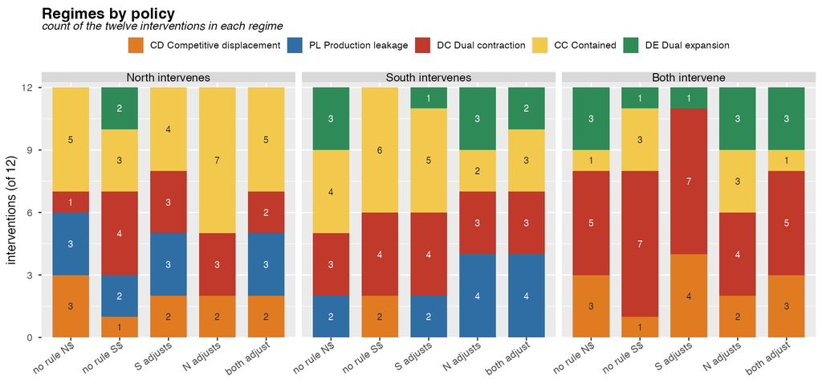

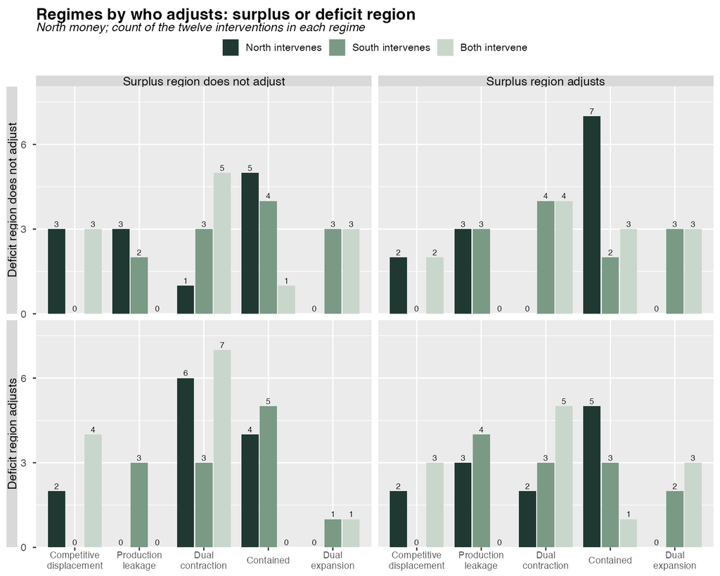

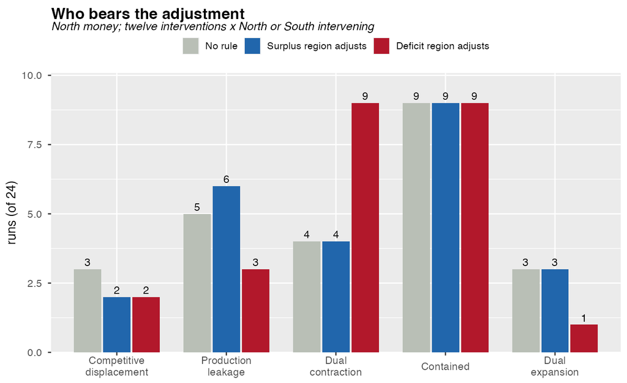

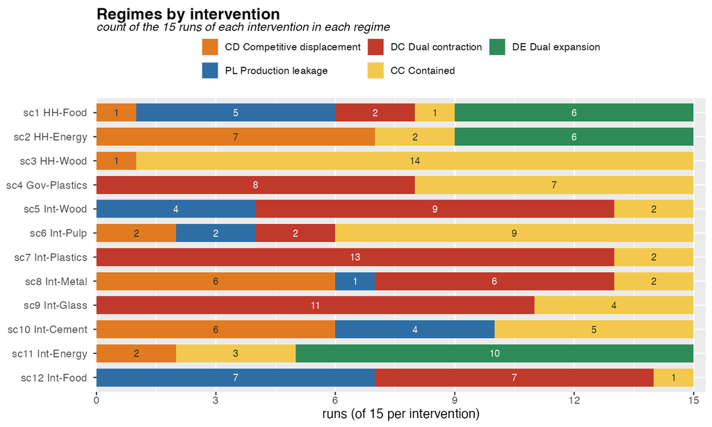

## Regimes: 60 runs: North intervenes, both monies

Each chip is the value-added regime of one run: an intervention (rows, in scenario order) carried out by the North, under no rule, North money, no rule, South money, South adjusts, North adjusts, both adjust. Hover a chip for its run.

| Intervention | North intervenes no rule N$ | North intervenes no rule S$ | North intervenes S adjusts | North intervenes N adjusts | North intervenes both adjust |
| --- | --- | --- | --- | --- | --- |
| **sc1 HH-Food** | PL | DE | PL | DC | PL |
| **sc2 HH-Energy** | CD | CD | CD | CD | CD |
| **sc3 HH-Wood** | CC | CC | CC | CC | CC |
| **sc4 Gov-Plastics** | DC | DC | DC | CC | DC |
| **sc5 Int-Wood** | PL | PL | PL | CC | PL |
| **sc6 Int-Pulp** | CC | CC | CC | CC | CC |
| **sc7 Int-Plastics** | CC | DC | CC | DC | DC |
| **sc8 Int-Metal** | CD | DC | DC | CD | CD |
| **sc9 Int-Glass** | CC | DC | DC | CC | CC |
| **sc10 Int-Cement** | CC | CC | CD | CC | CC |
| **sc11 Int-Energy** | CD | DE | CC | CC | CC |
| **sc12 Int-Food** | PL | PL | PL | DC | PL |

**All 60 runs:** CD Competitive displacement 10 PL Production leakage 11 DC Dual contraction 13 CC Contained 24 DE Dual expansion 2.

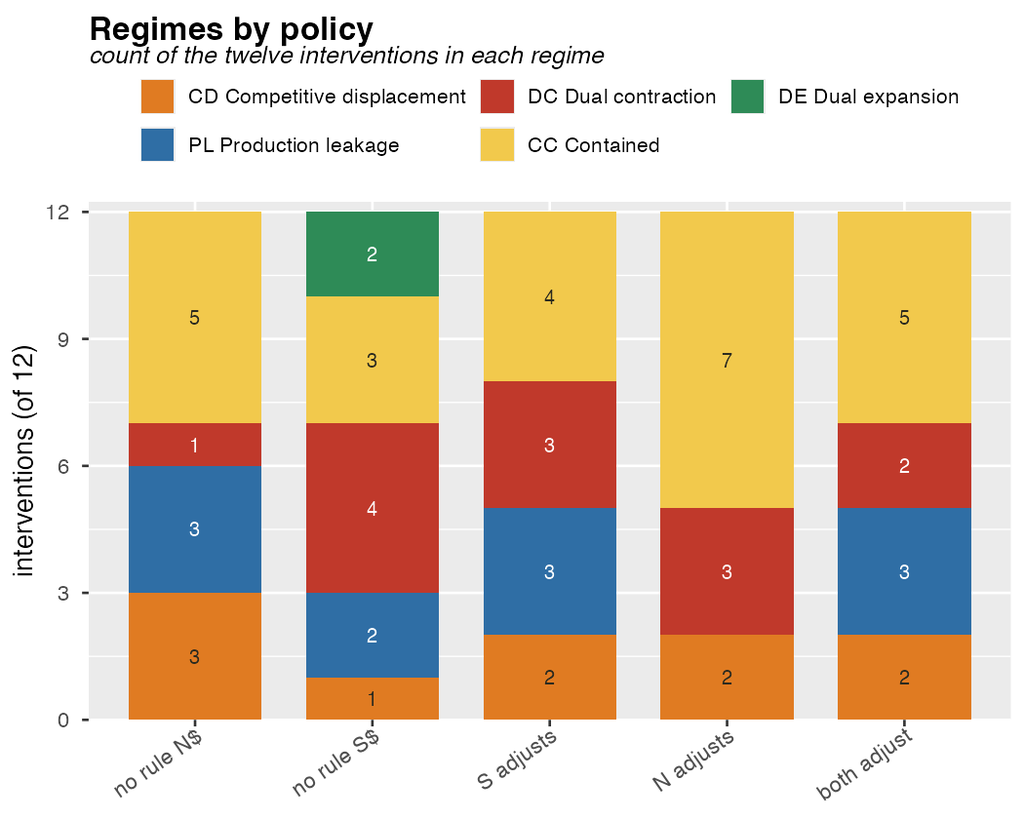

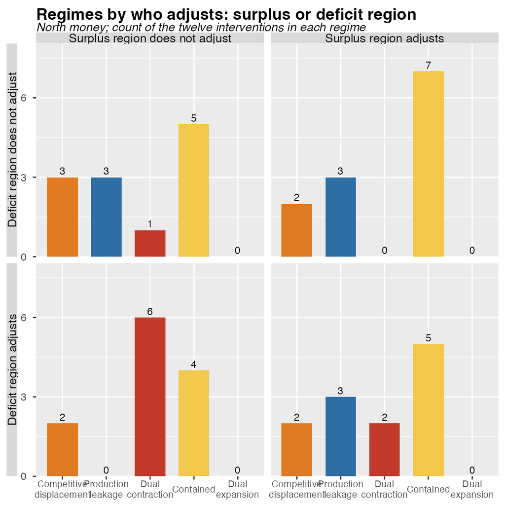

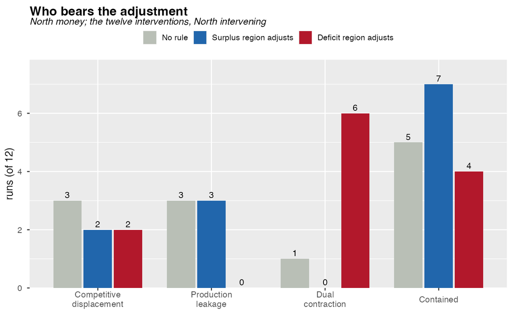

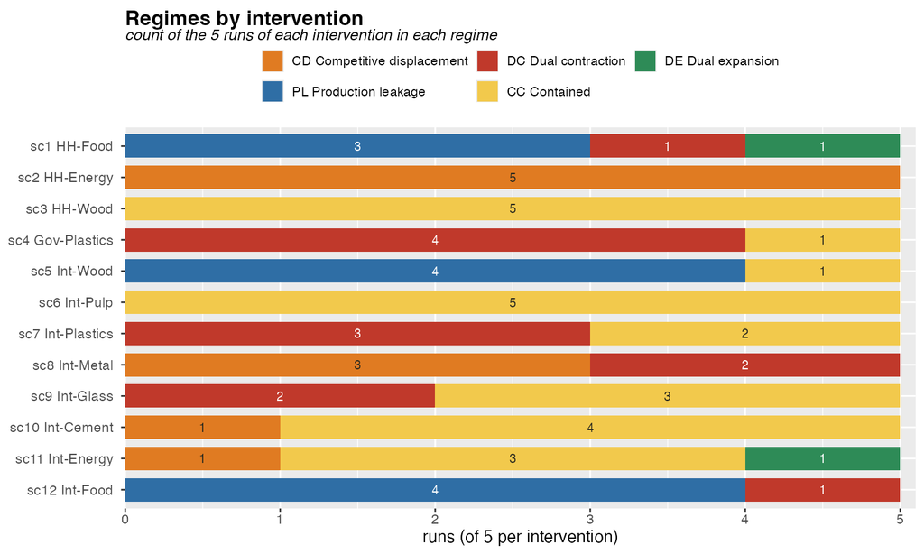

**Top right, regimes by who adjusts**, read by role, under North money only: the surplus region adjusting or not across the columns, the deficit region adjusting or not down the rows; top left is no rule, bottom right both adjusting. The deficit region is the one whose current account the intervention worsens with no rule, so which of North and South it is changes from one intervention to the next; labelled by name instead, the panels mix the two roles and the effect of the rule largely cancels. **Bottom left, who bears the adjustment**: the single-region rules by role. When the deficit region has to adjust, dual contraction becomes common; when the surplus region adjusts, it does not occur.

## Regimes: 48 runs: North intervenes, North money

Each chip is the value-added regime of one run: an intervention (rows, in scenario order) carried out by the North, under no rule, North money, South adjusts, North adjusts, both adjust. Hover a chip for its run.

| Intervention | North intervenes no rule N$ | North intervenes S adjusts | North intervenes N adjusts | North intervenes both adjust |
| --- | --- | --- | --- | --- |
| **sc1 HH-Food** | PL | PL | DC | PL |
| **sc2 HH-Energy** | CD | CD | CD | CD |
| **sc3 HH-Wood** | CC | CC | CC | CC |
| **sc4 Gov-Plastics** | DC | DC | CC | DC |
| **sc5 Int-Wood** | PL | PL | CC | PL |
| **sc6 Int-Pulp** | CC | CC | CC | CC |
| **sc7 Int-Plastics** | CC | CC | DC | DC |
| **sc8 Int-Metal** | CD | DC | CD | CD |
| **sc9 Int-Glass** | CC | DC | CC | CC |
| **sc10 Int-Cement** | CC | CD | CC | CC |
| **sc11 Int-Energy** | CD | CC | CC | CC |
| **sc12 Int-Food** | PL | PL | DC | PL |

**All 48 runs:** CD Competitive displacement 9 PL Production leakage 9 DC Dual contraction 9 CC Contained 21 DE Dual expansion 0.

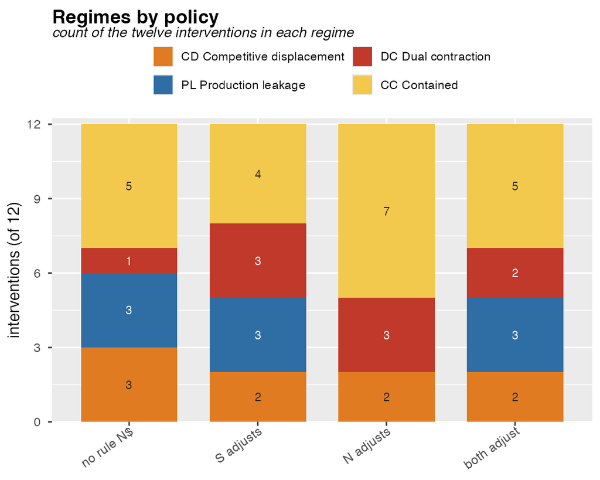

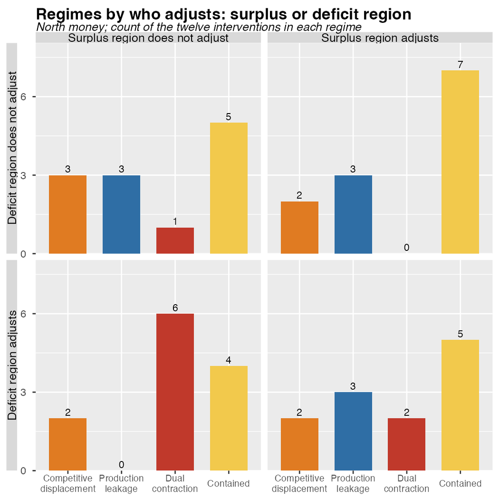

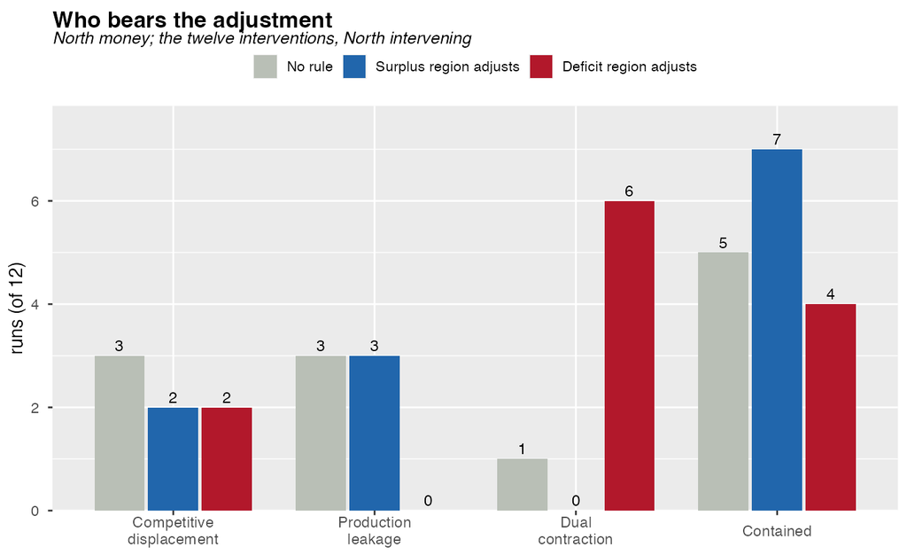

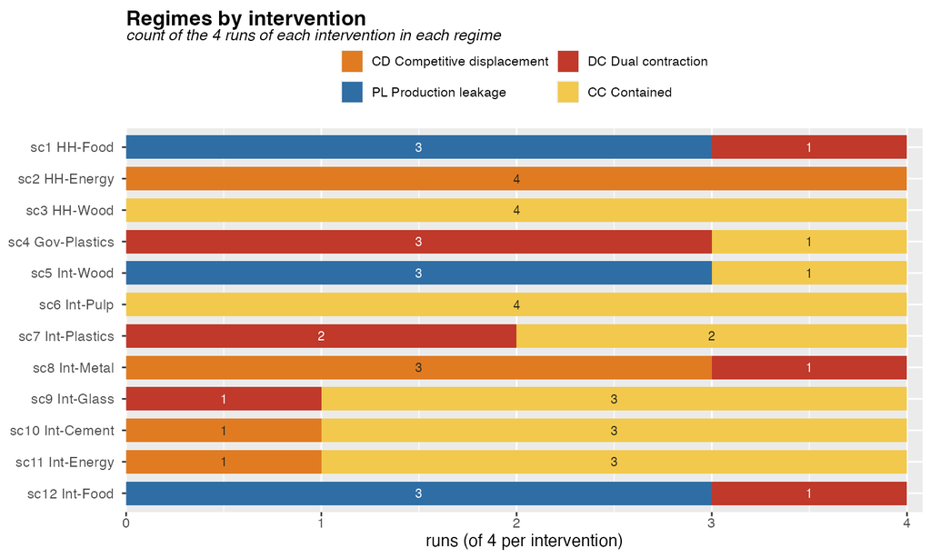

**Top right, regimes by who adjusts**, read by role, under North money only: the surplus region adjusting or not across the columns, the deficit region adjusting or not down the rows; top left is no rule, bottom right both adjusting. The deficit region is the one whose current account the intervention worsens with no rule, so which of North and South it is changes from one intervention to the next; labelled by name instead, the panels mix the two roles and the effect of the rule largely cancels. **Bottom left, who bears the adjustment**: the single-region rules by role. When the deficit region has to adjust, dual contraction becomes common; when the surplus region adjusts, it does not occur.

## Why the regimes differ: the South content of what is substituted

North intervening, no rule, North money. **Left figure:** each intervention's response by its size (the length of its response vector in the 48-run space, responses scaled by their sd and the six blocks weighted equally, not centred), its axis (the share of that length in each block) and its sign (the North current account). **Right figure:** the South content of the good the intervention substitutes away from (primary) and towards (secondary): South output per unit of North final demand for that good, from the Leontief inverse of the baseline input matrix (mean of t = 79-100).

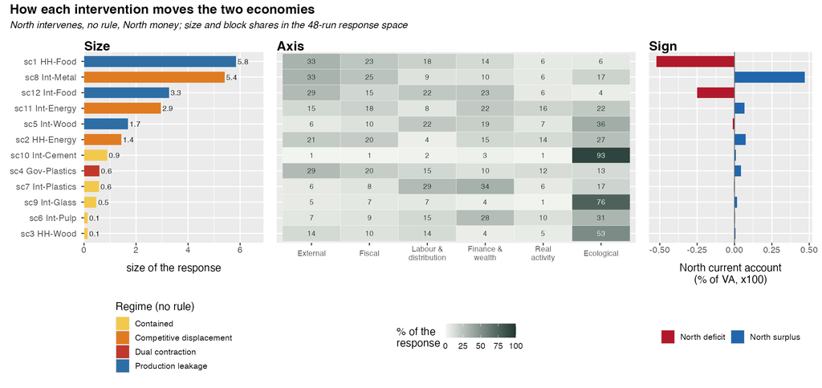

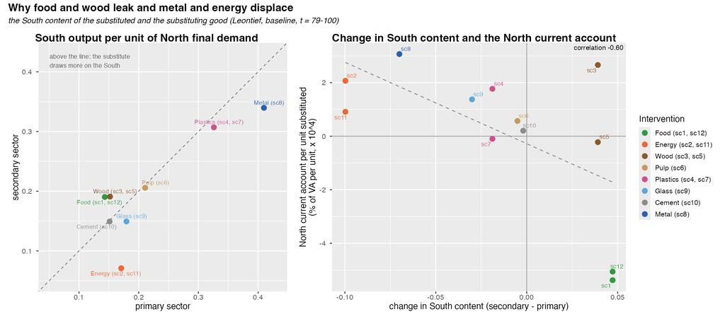

**Grid.** 180 runs: twelve interventions (sc1-sc12, a 20% substitution from period 70) x who intervenes (North, South, both) x five policies, North/South world under OPENFIX-fiat. Each response is the mean over periods 79-100 of the run's difference from its own no-intervention baseline. South emissions corrected ex post (D-77). Analysis tag `20261121_ce79`; no simulation is run by this page.